# Superstore Data Analysis

Analysis of a Kaggle Superstore dataset to explore general performance, customer behavior, and monthly trends, with th egoal to identify actionable business insights.

## Data Loading & Cleaning

Importing and inspecting the dataset from Kaggle, including checking for missing values and then cleaning the data.

```python
#load superstore data and check data

import pandas as pd

df = pd.read_csv("Superstore.csv", encoding='latin1')

print(df.head())
print(df.info())
```

```
   Row ID        Order ID  Order Date   Ship Date       Ship Mode Customer ID  \
0       1  CA-2016-152156   11/8/2016  11/11/2016    Second Class    CG-12520
1       2  CA-2016-152156   11/8/2016  11/11/2016    Second Class    CG-12520
2       3  CA-2016-138688   6/12/2016   6/16/2016    Second Class    DV-13045
3       4  US-2015-108966  10/11/2015  10/18/2015  Standard Class    SO-20335
4       5  US-2015-108966  10/11/2015  10/18/2015  Standard Class    SO-20335

     Customer Name    Segment        Country             City  ...  \
0      Claire Gute   Consumer  United States        Henderson  ...
1      Claire Gute   Consumer  United States        Henderson  ...
2  Darrin Van Huff  Corporate  United States      Los Angeles  ...
3   Sean O'Donnell   Consumer  United States  Fort Lauderdale  ...
4   Sean O'Donnell   Consumer  United States  Fort Lauderdale  ...

  Postal Code  Region       Product ID         Category Sub-Category  \
```

[output cut: 50 more lines]

```python
#clean data after checking

print(df.isnull().sum())    #missing values
print(df.duplicated().sum())    #duplicate values

df['Order Date'] = pd.to_datetime(df['Order Date'])   #converting dates
df['Year'] = df['Order Date'].dt.year
df['Month'] = df['Order Date'].dt.month
```

```
Row ID           0
Order ID         0
Order Date       0
Ship Date        0
Ship Mode        0
Customer ID      0
Customer Name    0
Segment          0
Country          0
City             0
State            0
Postal Code      0
Region           0
Product ID       0
Category         0
Sub-Category     0
Product Name     0
Sales            0
Quantity         0
Discount         0
Profit           0
Year             0
Month            0
dtype: int64
0
```

## Business Insights

Exploring sales performance across different aspects, including location, category, and segments to identify patterns.

```python
#analysis

print(f"Total Revenue: ${df['Sales'].sum():,.2f}")

print() #blank line
print("Top 10 Products by Revenue:")
top_products = df.groupby('Product Name')['Sales'].sum().sort_values(ascending = False).head(10)

for i, (product, sales) in enumerate(top_products.items(), start = 1):
    print(f"{i}. {product}")
    print(f"   Revenue: ${sales:,.2f}")
```

```
Total Revenue: $2,297,200.86

Top 10 Products by Revenue:
1. Canon imageCLASS 2200 Advanced Copier
   Revenue: $61,599.82
2. Fellowes PB500 Electric Punch Plastic Comb Binding Machine with Manual Bind
   Revenue: $27,453.38
3. Cisco TelePresence System EX90 Videoconferencing Unit
   Revenue: $22,638.48
4. HON 5400 Series Task Chairs for Big and Tall
   Revenue: $21,870.58
5. GBC DocuBind TL300 Electric Binding System
   Revenue: $19,823.48
6. GBC Ibimaster 500 Manual ProClick Binding System
   Revenue: $19,024.50
7. Hewlett Packard LaserJet 3310 Copier
   Revenue: $18,839.69
8. HP Designjet T520 Inkjet Large Format Printer - 24" Color
   Revenue: $18,374.90
9. GBC DocuBind P400 Electric Binding System
   Revenue: $17,965.07
10. High Speed Automatic Electric Letter Opener
   Revenue: $17,030.31
```

```python
print("States in Order by Revenue:")
state_order = df.groupby('State')['Sales'].sum().sort_values(ascending = False)

for i, (state, sales) in enumerate(state_order.items(), start = 1):
    print(f"{i}. {state}: ${sales:,.2f}")
```

```
States in Order by Revenue:
1. California: $457,687.63
2. New York: $310,876.27
3. Texas: $170,188.05
4. Washington: $138,641.27
5. Pennsylvania: $116,511.91
6. Florida: $89,473.71
7. Illinois: $80,166.10
8. Ohio: $78,258.14
9. Michigan: $76,269.61
10. Virginia: $70,636.72
11. North Carolina: $55,603.16
12. Indiana: $53,555.36
13. Georgia: $49,095.84
14. Kentucky: $36,591.75
15. New Jersey: $35,764.31
16. Arizona: $35,282.00
17. Wisconsin: $32,114.61
18. Colorado: $32,108.12
19. Tennessee: $30,661.87
20. Minnesota: $29,863.15
21. Massachusetts: $28,634.43
22. Delaware: $27,451.07
23. Maryland: $23,705.52
24. Rhode Island: $22,627.96
25. Missouri: $22,205.15
26. Oklahoma: $19,683.39
27. Alabama: $19,510.64
28. Oregon: $17,431.15
29. Nevada: $16,729.10
30. Connecticut: $13,384.36
31. Arkansas: $11,678.13
32. Utah: $11,220.06
33. Mississippi: $10,771.34
34. Louisiana: $9,217.03
35. Vermont: $8,929.37
36. South Carolina: $8,481.71
37. Nebraska: $7,464.93
38. New Hampshire: $7,292.52
39. Montana: $5,589.35
40. New Mexico: $4,783.52
41. Iowa: $4,579.76
42. Idaho: $4,382.49
43. Kansas: $2,914.31
44. District of Columbia: $2,865.02
45. Wyoming: $1,603.14
46. South Dakota: $1,315.56
47. Maine: $1,270.53
48. West Virginia: $1,209.82
49. North Dakota: $919.91
```

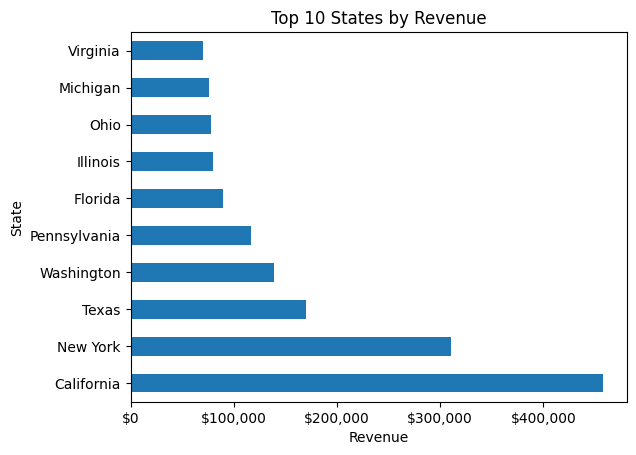

```python
import matplotlib.pyplot as plt
from matplotlib.ticker import FuncFormatter

top_states = df.groupby('State')['Sales'].sum().sort_values(ascending = False).head(10)

top_states.plot(kind = "barh")
plt.gca().xaxis.set_major_formatter(FuncFormatter(lambda x, _: f'${x:,.0f}'))
    #change formatting of revenue
plt.title("Top 10 States by Revenue")
plt.xlabel("Revenue")
plt.show()
```

```python
print("Top 10 Customers by Sales")
top_customers = df.groupby('Customer Name')['Sales'].sum().sort_values(ascending = False).head(10)

for i, (customer, sales) in enumerate(top_customers.items(), start = 1):
    print(f"{i}. {customer}: ${sales:,.2f}")
```

```
Top 10 Customers by Sales
1. Sean Miller: $25,043.05
2. Tamara Chand: $19,052.22
3. Raymond Buch: $15,117.34
4. Tom Ashbrook: $14,595.62
5. Adrian Barton: $14,473.57
6. Ken Lonsdale: $14,175.23
7. Sanjit Chand: $14,142.33
8. Hunter Lopez: $12,873.30
9. Sanjit Engle: $12,209.44
10. Christopher Conant: $12,129.07
```

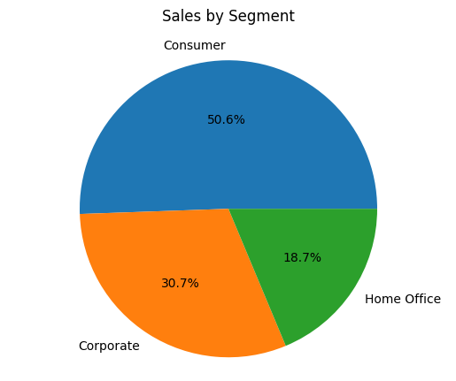

```python
segment = df.groupby('Segment')['Sales'].sum()

plt.pie(segment, labels = segment.index, autopct = '%1.1f%%')
plt.title('Sales by Segment', pad = 20)
plt.axis('equal')
plt.show()
```

## Monthly Trends

Analyzing monthly data to identify and understand patterns and fluctuations over time.

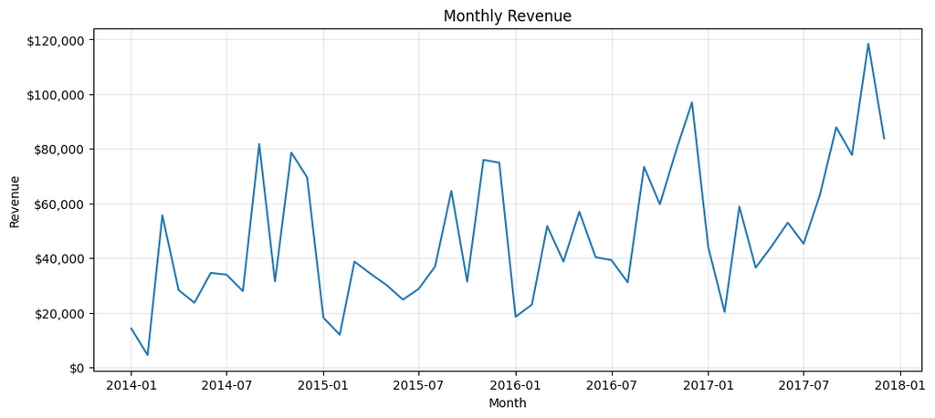

```python
#monthly data

#sales
monthly_sales = df.groupby(['Year', 'Month'])['Sales'].sum().reset_index()
monthly_sales['Date'] = pd.to_datetime(monthly_sales[['Year', 'Month']].assign(day = 1))

plt.figure(figsize = (12,5))
plt.plot(monthly_sales['Date'], monthly_sales['Sales'])
plt.gca().yaxis.set_major_formatter(FuncFormatter(lambda x, _: f'${x:,.0f}'))
    #change formatting of revenue

plt.title("Monthly Revenue")
plt.xlabel("Month")
plt.ylabel("Revenue")
plt.grid(alpha = 0.3)
plt.show()
print()
```

Revenue generally increased over the four year period, with noticeable dips in Q1 and spikes in Q4 each year. This pattern suggests seasonal fluctuations, with increased demands and purchasing activity during the holiday season followed by a post holiday slowdown.

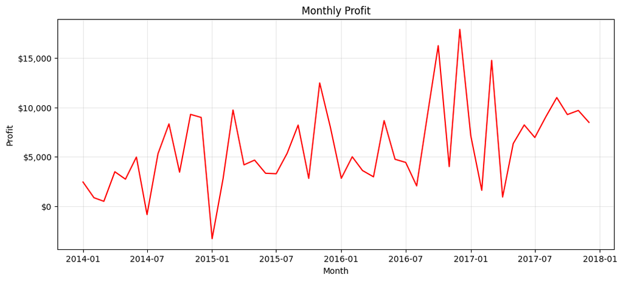

```python
#profit
monthly_profit = df.groupby(['Year', 'Month'])['Profit'].sum().reset_index()
monthly_profit['Date'] = pd.to_datetime(monthly_profit[['Year', 'Month']].assign(day = 1))

plt.figure(figsize = (12,5))
plt.plot(monthly_profit['Date'], monthly_profit['Profit'], color = 'red')
plt.gca().yaxis.set_major_formatter(FuncFormatter(lambda x, _: f'${x:,.0f}'))
    #change formatting of profit

plt.title("Monthly Profit")
plt.xlabel("Month")
plt.ylabel("Profit")
plt.grid(alpha = 0.3)
plt.show()
print()
```

Profit generally increased over the four year period, although with more frequent fluctuations compared to revenue. Similar to the trend with revenue, profit tended to spike in Q4 and dip during Q1, suggesting the seasonal purchasing behavior influences profitabiliy as well.

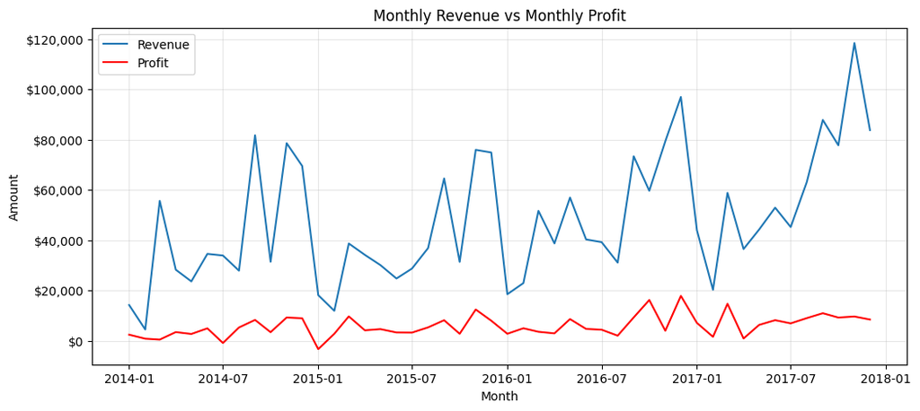

```python
#revenue vs profit
plt.figure(figsize = (12,5))
plt.plot(monthly_sales['Date'], monthly_sales['Sales'], label = "Revenue")
plt.plot(monthly_profit['Date'], monthly_profit['Profit'], label = "Profit", color = 'red')
plt.gca().yaxis.set_major_formatter(FuncFormatter(lambda x, _: f'${x:,.0f}'))
    #change formatting of amount

plt.title("Monthly Revenue vs Monthly Profit")
plt.xlabel("Month")
plt.ylabel("Amount")
plt.legend()
plt.grid(alpha = 0.3)
plt.show()
print()
```

Revenue and profit followed similar trends throughout the 4 year period, suggesting increased sales leads to increased profit. However, during the final months of the dataset, there was a heavier increase in revenue without a proportional increase in profit. This may indicate higher operating costs or increased discounting during that period.

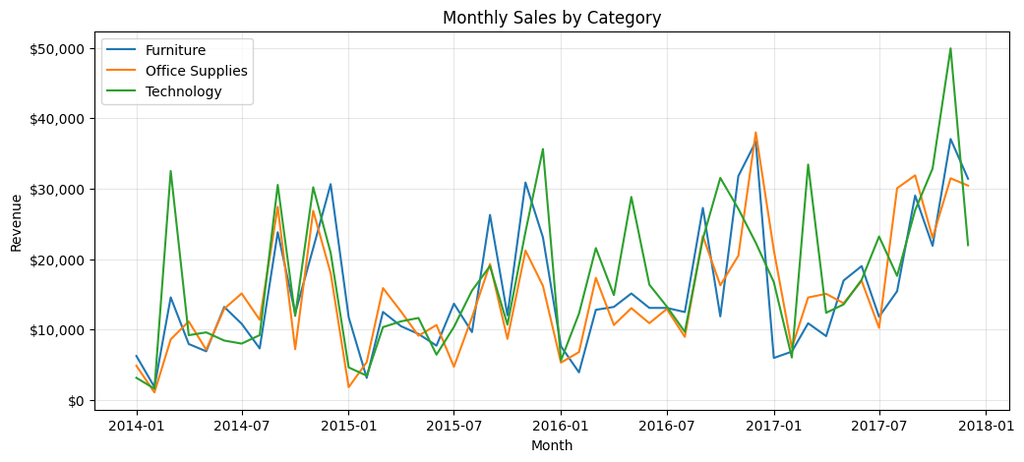

```python
#category
monthly_category = df.groupby(['Year', 'Month', 'Category'])['Sales'].sum().reset_index()
monthly_category['Date'] = pd.to_datetime(monthly_category[['Year', 'Month']].assign(day = 1))

plt.figure(figsize = (12,5))

for category in monthly_category['Category'].unique():
    c = monthly_category[monthly_category['Category'] == category]


    plt.plot(c['Date'], c['Sales'], label = category)
plt.gca().yaxis.set_major_formatter(FuncFormatter(lambda x, _: f'${x:,.0f}'))

plt.title("Monthly Sales by Category")
plt.xlabel("Month")
plt.ylabel("Revenue")
plt.legend()
plt.grid(alpha = 0.3)
plt.show()
print()
```

All three product categories followed similar trends throughout the 4 year period, with Technology having slighter greater spikes compared to Furniture and Office Supplies. Each category has shown overall growth within the 4 year period, while the pattern of Q4 spikes and Q1 dips further supports the presence of seasonal demand.

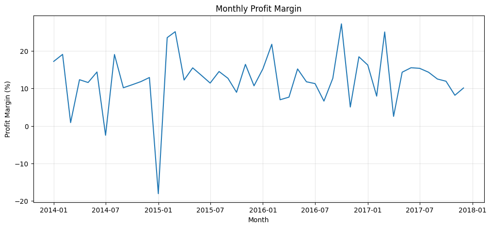

```python
#profit margin
monthly_margin = df.groupby(['Year', 'Month']).agg({'Sales':'sum', 'Profit':'sum'}).reset_index()
monthly_margin['Date'] = pd.to_datetime(monthly_margin[['Year', 'Month']].assign(day = 1))

monthly_margin['M Profit Margin'] = (monthly_margin['Profit']/monthly_margin['Sales'])*100

plt.figure(figsize = (12,5))
plt.plot(monthly_margin['Date'], monthly_margin['M Profit Margin'])

plt.title("Monthly Profit Margin")
plt.xlabel("Month")
plt.ylabel("Profit Margin (%)")
plt.grid(alpha = 0.3)
plt.show()
print()
```

Profit margin fluctuated throughout the 4 year period but generally stayed within the 10-20% margin. A notable dip occurred betweeen Q4 2014 and Q1 2015 indicating that profitabiliy decreased despite the continued sales. More data would be required to pinpoint the actual reason for the decline, but it may have been caused by more discounting or increased costs.

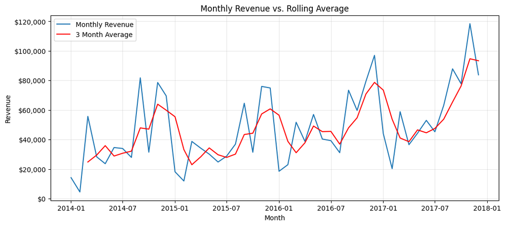

```python
#rolling 3 month
rolling = df.groupby(['Year', 'Month'])['Sales'].sum().reset_index()
rolling['Date'] = pd.to_datetime(rolling[['Year', 'Month']].assign(day = 1))

rolling['Avg'] = rolling['Sales'].rolling(window = 3).mean()

plt.figure(figsize = (12,5))
plt.plot(rolling['Date'], rolling['Sales'], label = 'Monthly Revenue')
plt.plot(rolling['Date'], rolling['Avg'], label = '3 Month Average', color = "red")
plt.gca().yaxis.set_major_formatter(FuncFormatter(lambda x, _: f'${x:,.0f}'))

plt.title("Monthly Revenue vs. Rolling Average")
plt.xlabel("Month")
plt.ylabel("Revenue")
plt.legend()
plt.grid(alpha = 0.3)
plt.show()
print()
```